# LS-GKM Evaluation Report

## Fold Information

Folds were made using combinations of chromosomes to have a similar loci count between them.

| Fold | Chromosomes | ELS loci | Missing negs |
| --- | --- | --- | --- |
| 1 | chr1, chr20, chr14, chr22 | 9,744 | 17 |
| 2 | chr2, chr12, chr9, chr13 | 9,583 | 10 |
| 3 | chr17, chr11, chr7, chr15, chrX | 9,995 | 20 |
| 4 | chr6, chr19, chr5, chr4, chr21 | 9,874 | 15 |
| 5 | chr3, chr16, chr10, chr8, chr18 | 10,229 | 15 |

An outer represents groups of folds on which a specific fold was left out of training and only used for testing. For instance the “outer1” model was trained using all folds except fold1 and then tested on fold1.

## LS-GKM SVM Params

LS-GKM SVM stands for large-scale, gapped k-mer support vector machine. This model uses a gapped-kmer tool to extract sequence features than can be used to train the vector machine. The following params were used:

- alphabet size( ${b}$): 4
- 1X negative synthetic data created from positive regulatory sequences
- ${\ell}$-mer with truncated function
- ${\ell}$-mer size (${\ell}$): 11
- number of informative columns (${k}$): 7
- max umber of mismatches: 4

The GKM tool creates a matrix M by N, where M is the number of all the possible gapped-kmer combinations, given ${\ell}$ and ${k}$, and N the total number of ungapped possibilites. The number of features depends on ${k}$, ${\ell}$, and ${b}$:

$$M = \binom{\ell}{k} b^k$$

# Dataset composition

The evaluation directory contains five held-out outer-fold prediction files and one consolidated out-of-fold prediction file.

Dataset composition by outer fold

| outer | n_total | n_positive | n_negative | positive_prevalence | minimum_seq_length | median_seq_length | maximum_seq_length |
| --- | --- | --- | --- | --- | --- | --- | --- |
| outer1 | 19,471 | 9,744 | 9,727 | 50.0% | 149 | 300 | 349 |
| outer2 | 19,156 | 9,583 | 9,573 | 50.0% | 149 | 305 | 349 |
| outer3 | 19,970 | 9,995 | 9,975 | 50.1% | 149 | 309 | 349 |
| outer4 | 19,733 | 9,874 | 9,859 | 50.0% | 149 | 301 | 349 |
| outer5 | 20,443 | 10,229 | 10,214 | 50.0% | 149 | 307 | 349 |

Pooled out-of-fold dataset composition

| n_total | n_positive | n_negative | positive_prevalence | n_outer_folds | minimum_seq_length | median_seq_length | maximum_seq_length |
| --- | --- | --- | --- | --- | --- | --- | --- |
| 98,773 | 49,425 | 49,348 | 50.0% | 5 | 149 | 305 | 349 |

# Per-fold summary table

Threshold-independent metrics use the continuous LS-GKM score. Threshold-based metrics use a classification threshold of 0.

Performance by outer fold

Threshold-based metrics use score >= 0

| outer_fold | n_positive | n_negative | positive_prevalence | roc_auc | average_precision | balanced_accuracy | mcc | sensitivity | specificity | precision | f1 |
| --- | --- | --- | --- | --- | --- | --- | --- | --- | --- | --- | --- |
| outer1 | 9,744 | 9,727 | 50.0% | 0.829 | 0.814 | 0.749 | 0.498 | 0.750 | 0.748 | 0.749 | 0.750 |
| outer2 | 9,583 | 9,573 | 50.0% | 0.842 | 0.831 | 0.764 | 0.528 | 0.773 | 0.755 | 0.759 | 0.766 |
| outer3 | 9,995 | 9,975 | 50.1% | 0.835 | 0.823 | 0.755 | 0.511 | 0.775 | 0.735 | 0.746 | 0.760 |
| outer4 | 9,874 | 9,859 | 50.0% | 0.840 | 0.827 | 0.760 | 0.520 | 0.773 | 0.748 | 0.754 | 0.763 |
| outer5 | 10,229 | 10,214 | 50.0% | 0.843 | 0.831 | 0.762 | 0.525 | 0.784 | 0.741 | 0.752 | 0.767 |

Distribution of performance across outer folds

| metric | mean | sd |
| --- | --- | --- |
| roc_auc | 0.838 | 0.006 |
| average_precision | 0.825 | 0.007 |
| balanced_accuracy | 0.758 | 0.006 |
| mcc | 0.516 | 0.012 |
| sensitivity | 0.771 | 0.012 |
| specificity | 0.745 | 0.008 |
| precision | 0.752 | 0.005 |
| f1 | 0.761 | 0.007 |

# ROC curves

## ROC curves by outer fold

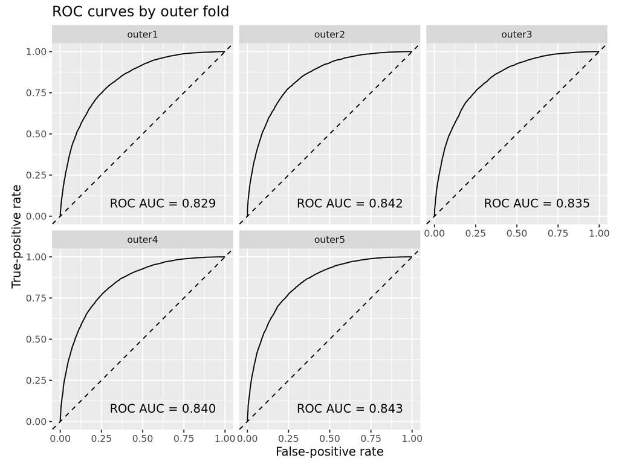

## Pooled out-of-fold ROC curve

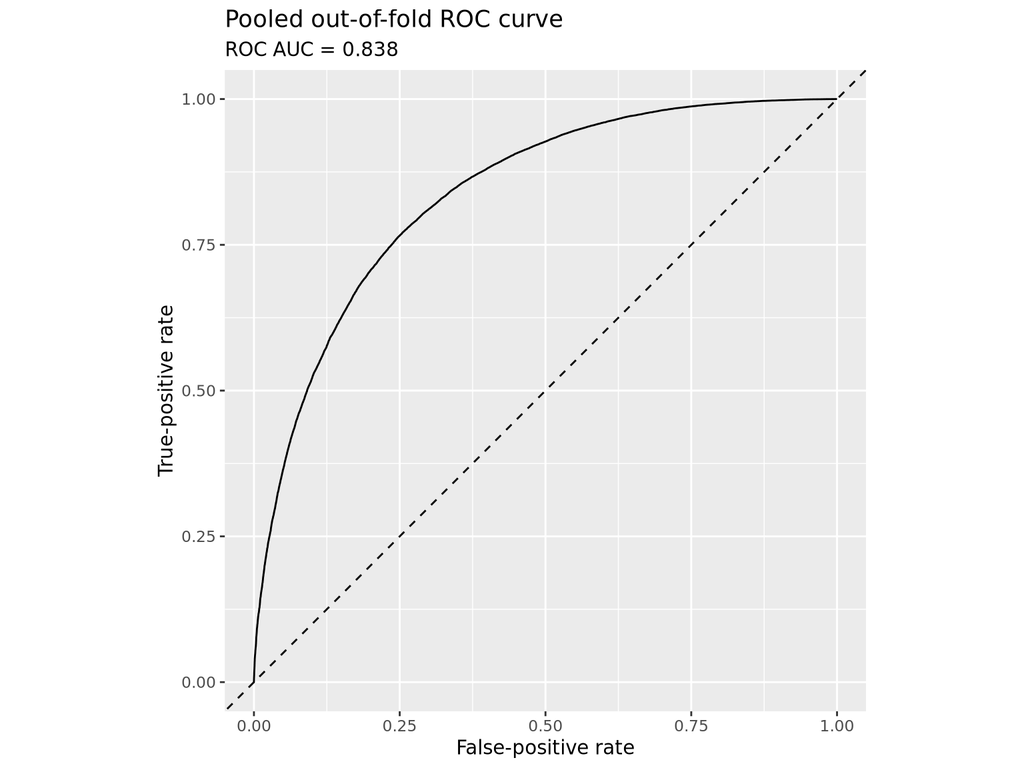

# Precision–recall curves

## Precision–recall curves by outer fold

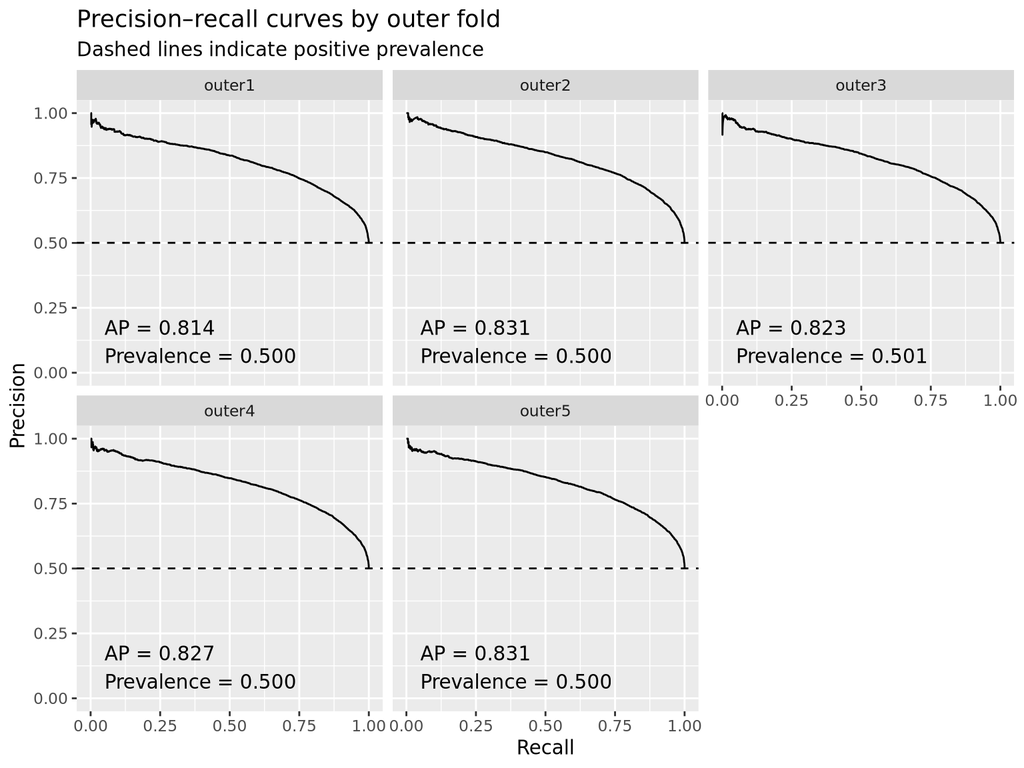

## Pooled out-of-fold precision–recall curve

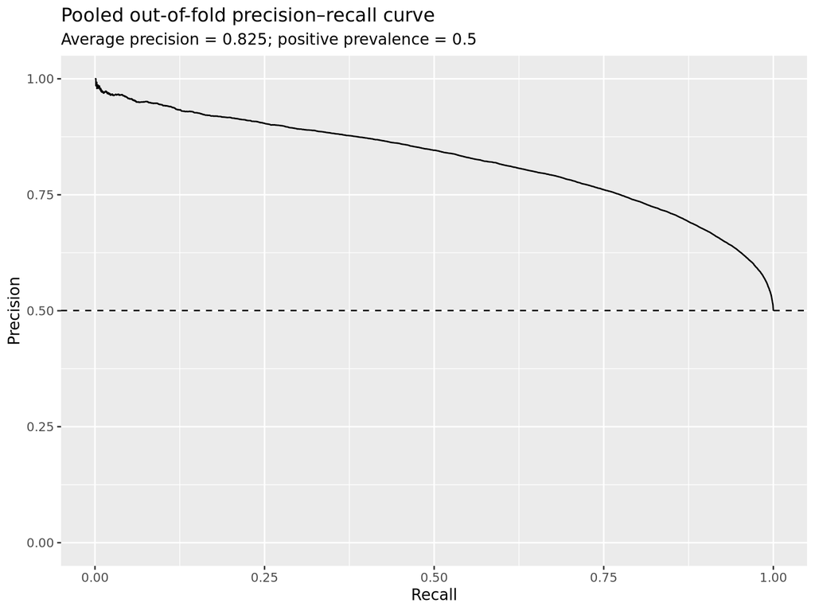

# Pooled out-of-fold performance

The pooled results combine predictions from all five held-out outer folds. Every observation in this table was scored by a model that did not train on that observation’s chromosome group.

Pooled out-of-fold performance

Threshold-based metrics use score >= 0

| outer_fold | n_positive | n_negative | positive_prevalence | roc_auc | average_precision | balanced_accuracy | mcc | sensitivity | specificity | precision | f1 |
| --- | --- | --- | --- | --- | --- | --- | --- | --- | --- | --- | --- |
| all_outer | 49,425 | 49,348 | 50.0% | 0.838 | 0.825 | 0.758 | 0.516 | 0.771 | 0.745 | 0.752 | 0.761 |

Pooled performance versus fold-level distribution

| metric | pooled | fold_mean | fold_sd |
| --- | --- | --- | --- |
| ROC AUC | 0.838 | 0.838 | 0.006 |
| Average precision | 0.825 | 0.825 | 0.007 |
| Balanced accuracy | 0.758 | 0.758 | 0.006 |
| MCC | 0.516 | 0.516 | 0.012 |
| Sensitivity | 0.771 | 0.771 | 0.012 |
| Specificity | 0.745 | 0.745 | 0.008 |
| Precision | 0.752 | 0.752 | 0.005 |
| F1 | 0.761 | 0.761 | 0.007 |

# Interpretation

The pooled out-of-fold ROC AUC was **0.838**, while the mean ROC AUC across the five outer folds was **0.838 ± 0.006**.

The pooled average precision was **0.825**, compared with a positive prevalence of **0.500**. The mean average precision across folds was **0.825 ± 0.007**.

ROC AUC ranged from **0.829** in `outer1` to **0.843** in `outer5`. Average precision ranged from **0.814** in `outer1` to **0.831** in `outer2`.

At the fixed decision threshold of **0.00**, pooled sensitivity was **0.771** and pooled specificity was **0.745**. These values describe performance at this specific threshold and should be interpreted separately from ROC AUC and average precision.

Differences between folds may reflect variation in the chromosome groups assigned to each held-out fold. Fold-level variability should therefore be considered alongside the pooled result rather than relying on the pooled result alone.

# Reproducibility

## Input files

Files used to generate this report

| file | path | rows |
| --- | --- | --- |
| outer1.tsv | /work/zarazuanav/workspace/repos/ccre-classification/results/evn/ls-gkm/outer1.tsv | 19,471 |
| outer2.tsv | /work/zarazuanav/workspace/repos/ccre-classification/results/evn/ls-gkm/outer2.tsv | 19,156 |
| outer3.tsv | /work/zarazuanav/workspace/repos/ccre-classification/results/evn/ls-gkm/outer3.tsv | 19,970 |
| outer4.tsv | /work/zarazuanav/workspace/repos/ccre-classification/results/evn/ls-gkm/outer4.tsv | 19,733 |
| outer5.tsv | /work/zarazuanav/workspace/repos/ccre-classification/results/evn/ls-gkm/outer5.tsv | 20,443 |
| all_outer.tsv | /work/zarazuanav/workspace/repos/ccre-classification/results/evn/ls-gkm/all_outer.tsv | 98,773 |